# Praca Domowa 3

## Wprowadzenie

W ramach pracy domowej przeprowadziłam dwa eksperymenty. Te same dane przedstawiłam na różnych wykresach i utworzyłam ankietę, która miała na celu sprawdzenie występujących błędów w odczytywaniu wykresów ( iluzje na wykresach, czy problemy z odczytywaniem wykresu kołowego oraz “lustrzanego” ). W ankiecie wzięło udział 15 osób.

Link do ankiety: https://docs.google.com/forms/d/e/1FAIpQLSfKfu3hHxmHeSkrijBuoh3RHJC5tGDvuqtPS55PMKCLOx63OA/viewform?usp=sf_link

### Porównanie wykresu słupkowego oraz kołowego

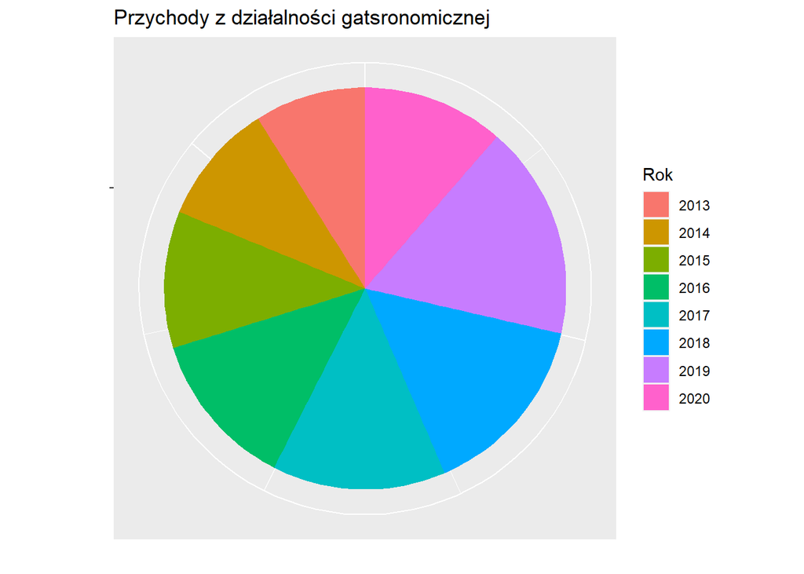

```r
pie_plot(df2)
```

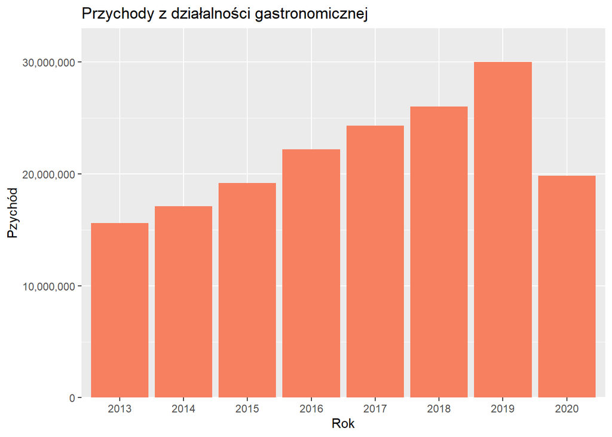

```r
bar_plot(df2)
```

#### Pytania do wykresów

1. W którym roku były najmniejsze przychody?
2. Porównanie przychodów w 2020 i 2016 roku (W którym roku były większe?)

Na pytanie “W którym roku były najmniejsze przychody?” 13% ankietowanych (2 osoby) odpowiedziało błędnie zaznaczając 2014 rok pod wykresem kołowym.

Z wykresu słupkowego 100% osób odczytało poprawną odpowiedź.

Na pytanie 2 35% osób odczytał źle dane z wykresu kołowego i zaznaczyło, że przychody w 2020 i 2016 roku były takie same. 7 % osób zanaczyło, że w 2016 roku przychody były mniejsze niż w 2020. Tylko 57 % sposród ankietowanych odpowiedziało poprawnie zaznaczając, że przychodzy uzyskane w 2016 roku były większe niż w 2020 %

Na to samo pytanie pod wykresem słupkowym 100 % osób odpowiedziało poprawnie.

Wszyscy ankietowani zaznaczyli, ż na wykresie słupkowym było im łatwiej odczytać dane.

### Porównanie wykresu “lustrzanego” oraz słupkowego

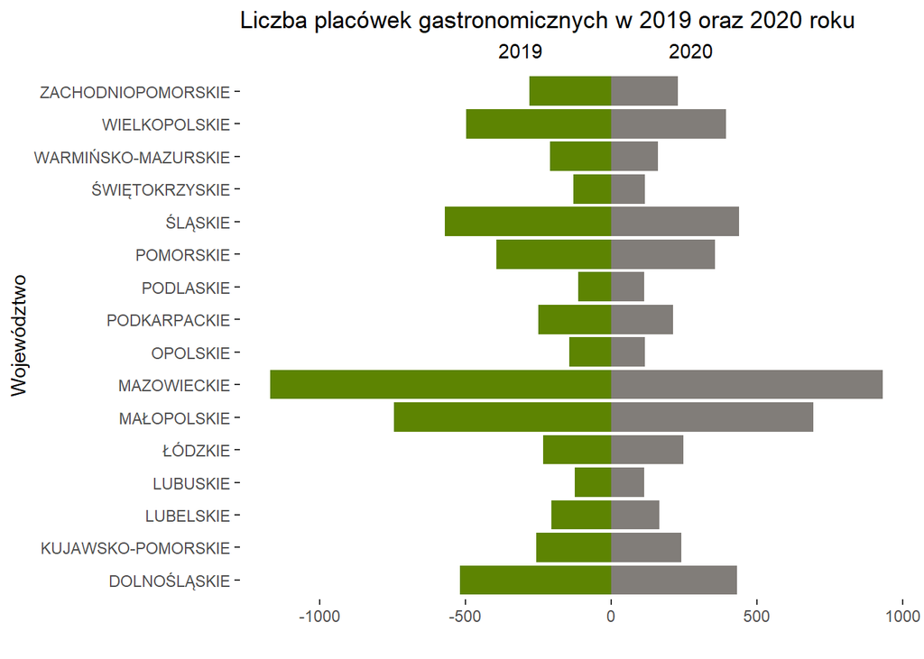

```r
mirror_plot(df)
```

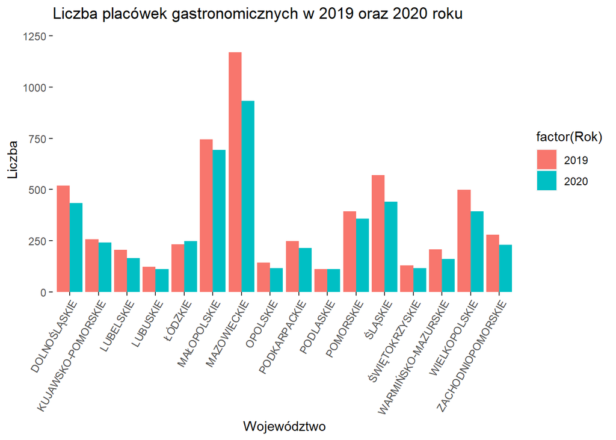

```r
bar_grouped_plot(df1)
```

#### Pytania do wykresów

1. W którym roku w województwie Lubuskim było więcej placówek?
2. W którym roku w województwie Pomorskim było więcej placówek?

Pod wykresem lustrzanym, na pierwsze pytanie aż 60 % ankietowanych odpowiedziało błędnie zaznaczając, że liczba placówek jest taka sama (40%) oraz rok 2020 (20%). Tylko 40 % odpowiedziało poprawnie i wybrało rok 2019.

Z wykresu słupkowego 87% osób odczytało dane poprawnie, a pozostałe 2 osoby błędnie zaznaczyły rok 2020.

Na podstawie wykresu lustrzanego 73% osób odpowiedziało poprawnie wybierając rok 2019.Po 2 osoby zaznaczyły błędnie rok 2020 oraz odpowiedź “liczba placówek nie zmieniła się”.

Wszyscy opórcz jednej osoby odczytało poprawnie dane odpowiadając na to samo pytanie na podstawie wykresu słupkowego. 1 osoba zaznaczyła błędnie, że liczba placówek nie zmieniła się.

### Porównanie wykresu słupkowego z siatką oraz bez siatki

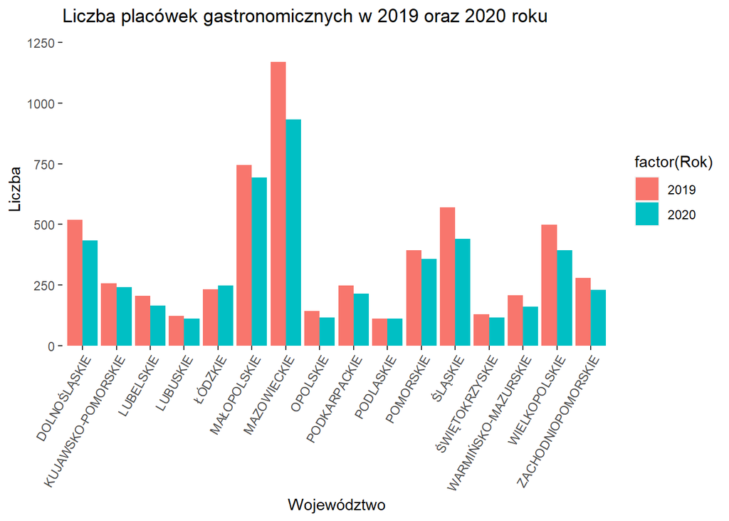

```r
bar_grouped_plot(df1)
```

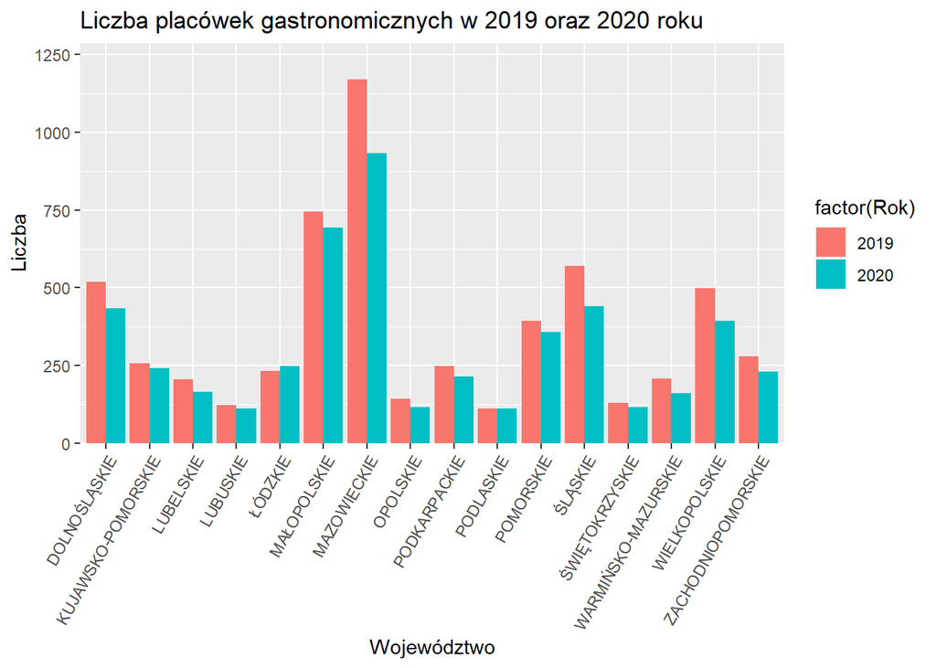

```r
bar_grouped_plot2(df1)
```

#### Pytanie do wykresów

1. Porównaj liczbę placówek w 2020 roku w woj. Śląskim oraz Dolnośląskim. Gdzie była większa?

Na koniec postanowiłam również dodać jedno pytanie, na które trzeba było odpowiedzieć dwukrotnie, najpierw na podstawie wykresu słupkowego z bialym tłem, a następnie z siatką w tle.

Odczytując dane z wykresu, na którym było białe tło aż 73 % osób odpowiedziało błędnie. 60% osób zaznczayło, że liczba placówek w 2020 roku w woj. Śląskim oraz Dolnośląskim była taka sama, oraz 13%, że w woj. Dolnośląskim była większa. Tylko 4 osoby spośród 15 udzieliło poprawnej odpowiedzi.

Pod wykresem z siatką 13% i 20% osób odpowiedziało odpowiednio, że liczba w woj.Dolnośląskim była większa oraz, że liczba była taka sama. 10 na 15 osób udzieliło poprawnie odczytalo, że w woj. Śląskim liczba była większa.

Wszyscy odpowiedzieli, że łatwiej było im odczytać dane z wykresu z siatką.